# Dealing with Missing Data

Ryan Hawkins

November 24, 2018

# Introduction to Missing Data

## Using and finding missing values

When working with missing data, there are a couple of commands that you should be familiar with - firstly, you should be able to identify if there are any missing values, and where these are.

Using the any_na() and are_na() tools, identify which values are missing.

```r
library(naniar)
library(tidyverse)
# Create x, a vector, with values NA, NaN, Inf, ".", and "missing"
x <- c(NA, NaN, Inf, ".", "missing")

# Use any_na() and are_na() on to explore the missings
any_na(x)
```

```
## [1] TRUE
```

```r
are_na(x)
```

```
## [1]  TRUE FALSE FALSE FALSE FALSE
```

## How many missing values are there?

One of the first things that you will want to check with a new dataset is if there are any missing missing values, and how many there are.

You could use are_na() to and count up the missing values, but the most efficient way to count missings is to use the n_miss() function. This will tell you the total number of missing values in the data.

You can then find the percent of missing values in the data with the pct_miss function. This will tell you the percentage of missing values in the data.

You can also find the complement to these - how many complete values there are - using n_complete and pct_complete.

```r
# Use n_miss() to count the total number of missing values in dat_hw
n_miss(oceanbuoys)
```

```
## [1] 177
```

```r
# Use n_miss() on dat_hw$weight to count the total number of missing values
n_miss(oceanbuoys$air_temp_c)
```

```
## [1] 81
```

```r
# Use n_complete() on dat_hw to count the total number of complete values
n_complete(oceanbuoys)
```

```
## [1] 5711
```

```r
# Use n_complete() on dat_hw$weight to count the total number of complete values
n_complete(oceanbuoys$air_temp_c)
```

```
## [1] 655
```

```r
# Use prop_miss() and prop_complete() on dat_hw to count the total number of missing values in each of the variables
prop_miss(oceanbuoys)
```

```
## [1] 0.03006114
```

```r
prop_complete(oceanbuoys)
```

```
## [1] 0.9699389
```

## Summarizing missingness

Now that you understand the behavior of missing values in R, and how to count them, let’s scale up our summaries for cases (rows) and variables, using miss_var_summary() and miss_case_summary(), and also explore how they can be applied for groups in a dataframe, using the group_by function from dplyr.

```r
# Summarise missingness in each variable of the `airquality` dataset
miss_var_summary(airquality)
```

```
## # A tibble: 6 x 3
##   variable n_miss pct_miss
##   <chr>     <int>    <dbl>
## 1 Ozone        37    24.2
## 2 Solar.R       7     4.58
## 3 Wind          0     0
## 4 Temp          0     0
## 5 Month         0     0
## 6 Day           0     0
```

```r
# Summarise missingness in each case of the `airquality` dataset
miss_case_summary(airquality)
```

```
## # A tibble: 153 x 3
##     case n_miss pct_miss
##    <int>  <int>    <dbl>
##  1     5      2     33.3
##  2    27      2     33.3
##  3     6      1     16.7
##  4    10      1     16.7
##  5    11      1     16.7
##  6    25      1     16.7
##  7    26      1     16.7
##  8    32      1     16.7
##  9    33      1     16.7
## 10    34      1     16.7
## # ... with 143 more rows
```

```r
# Return the summary of missingness in each variable, grouped by Month, in the `airquality` dataset
airquality %>% group_by(Month) %>% miss_var_summary()
```

```
## # A tibble: 25 x 4
##    Month variable n_miss pct_miss
##    <int> <chr>     <int>    <dbl>
##  1     5 Ozone         5     16.1
##  2     5 Solar.R       4     12.9
##  3     5 Wind          0      0
##  4     5 Temp          0      0
##  5     5 Day           0      0
##  6     6 Ozone        21     70
##  7     6 Solar.R       0      0
##  8     6 Wind          0      0
##  9     6 Temp          0      0
## 10     6 Day           0      0
## # ... with 15 more rows
```

```r
# Return the summary of missingness in each case, grouped by Month, in the `airquality` dataset
airquality %>% group_by(Month) %>% miss_case_summary()
```

```
## # A tibble: 153 x 4
##    Month  case n_miss pct_miss
##    <int> <int>  <int>    <dbl>
##  1     5     5      2       40
##  2     5    27      2       40
##  3     5     6      1       20
##  4     5    10      1       20
##  5     5    11      1       20
##  6     5    25      1       20
##  7     5    26      1       20
##  8     5     1      0        0
##  9     5     2      0        0
## 10     5     3      0        0
## # ... with 143 more rows
```

## Tabulating Missingness

The summaries of missingness we just calculated give us the number and percentage of missing observations for the cases and variables.

Another way to summarise missingness is by tabulating the number of times that there are 0, 1, 2, 3, missings in a variable, or in a case.

In this exercise we are going to tabulate the number of missings in each case and variable using miss_var_table() and miss_case_table(), and also combine these summaries with the the group_by operator from dplyr. to explore the summaries over a grouping variable in the dataset.

```r
# Tabulate missingness in each variable and case of the `airquality` dataset
miss_var_table(airquality)
```

```
## # A tibble: 3 x 3
##   n_miss_in_var n_vars pct_vars
##           <int>  <int>    <dbl>
## 1             0      4     66.7
## 2             7      1     16.7
## 3            37      1     16.7
```

```r
miss_case_table(airquality)
```

```
## # A tibble: 3 x 3
##   n_miss_in_case n_cases pct_cases
##            <int>   <int>     <dbl>
## 1              0     111     72.5
## 2              1      40     26.1
## 3              2       2      1.31
```

```r
# Tabulate the missingness in each variable, grouped by Month, in the `airquality` dataset
airquality %>% group_by(Month) %>% miss_var_table()
```

```
## # A tibble: 12 x 4
##    Month n_miss_in_var n_vars pct_vars
##    <int>         <int>  <int>    <dbl>
##  1     5             0      3       60
##  2     5             4      1       20
##  3     5             5      1       20
##  4     6             0      4       80
##  5     6            21      1       20
##  6     7             0      4       80
##  7     7             5      1       20
##  8     8             0      3       60
##  9     8             3      1       20
## 10     8             5      1       20
## 11     9             0      4       80
## 12     9             1      1       20
```

```r
# Tabulate of missingness in each case, grouped by Month, in the `airquality` dataset
airquality %>% group_by(Month) %>% miss_case_table()
```

```
## # A tibble: 11 x 4
##    Month n_miss_in_case n_cases pct_cases
##    <int>          <int>   <int>     <dbl>
##  1     5              0      24     77.4
##  2     5              1       5     16.1
##  3     5              2       2      6.45
##  4     6              0       9     30
##  5     6              1      21     70
##  6     7              0      26     83.9
##  7     7              1       5     16.1
##  8     8              0      23     74.2
##  9     8              1       8     25.8
## 10     9              0      29     96.7
## 11     9              1       1      3.33
```

## Other summaries of missingness

Some summaries of missingness are particularly useful for different types of data. For example, miss_var_span() and miss_var_run().

miss_var_span() calculates the number of missing values in a specified variable for a repeating span. This is really useful in time series data, to look for weekly (7 day) patterns of missingness

miss_var_run() calculates the number of “runs” or “streaks” of missingness. This is useful to find unusual patterns of missingness, for example, you might find a repeating pattern of 5 complete and 5 missings.

Both miss_var_span() and miss_var_run() work with the group_by operator from dplyr.

```r
# Calculate the summaries for each run of missingness for the variable, hourly_counts
miss_var_run(pedestrian, var = hourly_counts)
```

```
## # A tibble: 35 x 2
##    run_length is_na
##         <int> <chr>
##  1       6628 complete
##  2          1 missing
##  3       5250 complete
##  4        624 missing
##  5       3652 complete
##  6          1 missing
##  7       1290 complete
##  8        744 missing
##  9       7420 complete
## 10          1 missing
## # ... with 25 more rows
```

```r
# Calculate the summaries for each span of missingness, for a span of 4000, for the variable hourly_counts
miss_var_span(pedestrian, var = hourly_counts, span_every = 4000)
```

```
## # A tibble: 10 x 5
##    span_counter n_miss n_complete prop_miss prop_complete
##           <int>  <int>      <dbl>     <dbl>         <dbl>
##  1            1      0       4000   0               1
##  2            2      1       3999   0.00025         1.000
##  3            3    121       3879   0.0302          0.970
##  4            4    503       3497   0.126           0.874
##  5            5    745       3255   0.186           0.814
##  6            6      0       4000   0               1
##  7            7      1       3999   0.00025         1.000
##  8            8      0       4000   0               1
##  9            9    745       3255   0.186           0.814
## 10           10    432       3568   0.108           0.892
```

```r
# For each `month` variable, calculate the run of missingness for hourly_counts
pedestrian %>% group_by(month) %>% miss_var_run(var = hourly_counts)
```

```
## # A tibble: 51 x 3
##    month    run_length is_na
##    <ord>         <int> <chr>
##  1 January        2976 complete
##  2 February       2784 complete
##  3 March          2976 complete
##  4 April           888 complete
##  5 April           552 missing
##  6 April          1440 complete
##  7 May             744 complete
##  8 May              72 missing
##  9 May            2160 complete
## 10 June           2880 complete
## # ... with 41 more rows
```

```r
# For each `month` variable, calculate the span of missingness of a span of 2000, for the variable hourly_counts
pedestrian %>% group_by(month) %>% miss_var_span(var = hourly_counts, span_every = 2000)
```

```
## # A tibble: 25 x 6
##    month    span_counter n_miss n_complete prop_miss prop_complete
##    <ord>           <int>  <int>      <dbl>     <dbl>         <dbl>
##  1 January             1      0       2000     0             1
##  2 January             2      0       2000     0             1
##  3 February            1      0       2000     0             1
##  4 February            2      0       2000     0             1
##  5 March               1      0       2000     0             1
##  6 March               2      0       2000     0             1
##  7 April               1    552       1448     0.276         0.724
##  8 April               2      0       2000     0             1
##  9 May                 1     72       1928     0.036         0.964
## 10 May                 2      0       2000     0             1
## # ... with 15 more rows
```

## Your first missing data visualizations

It can be difficult to get a handle on where the missing values are in your data, and here is where visualization can really help.

The function vis_miss() creates an overview visualization of the missingness in the data. It also has options to cluster rows based on missingness, using cluster = TRUE; as well as options for sorting the columns, from most missing to least missing (sort_miss = TRUE).

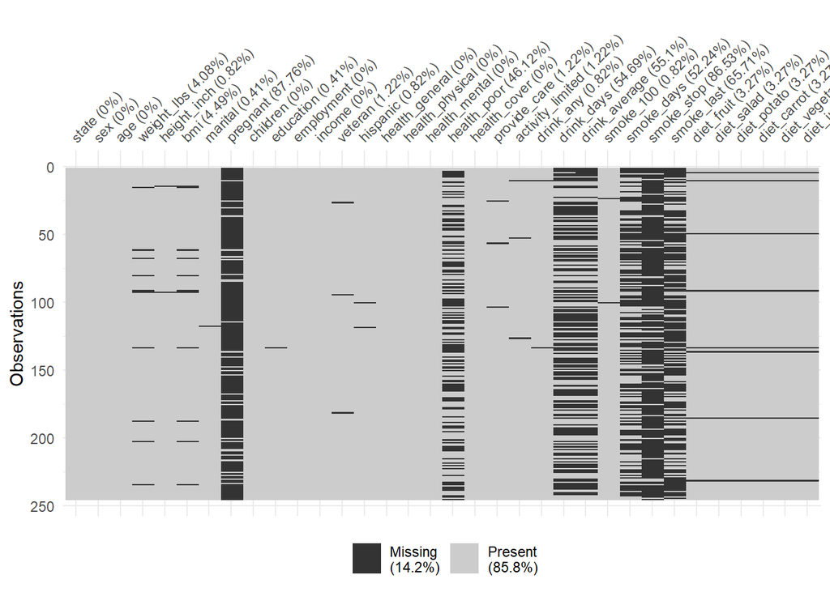

```r
# Visualize all of the missingness in the `riskfactors`  dataset
vis_miss(riskfactors)
```

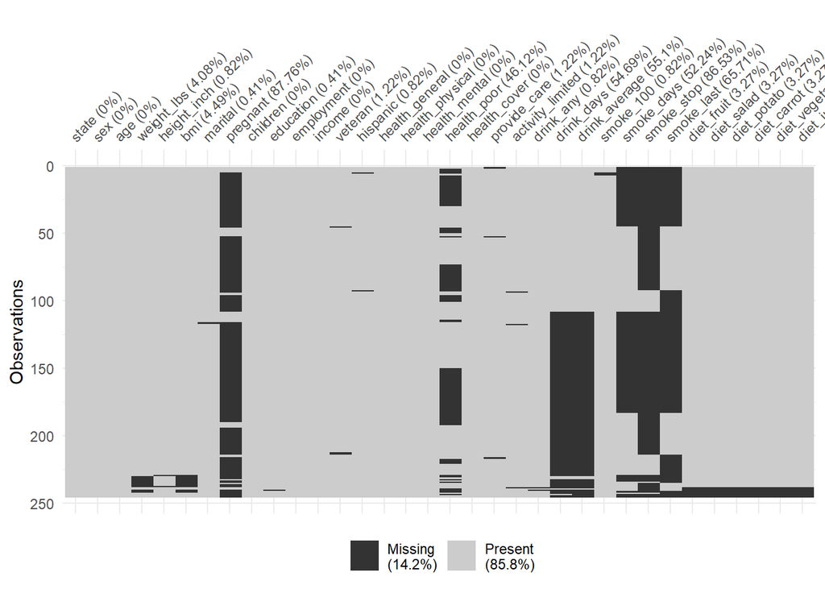

```r
# Visualize and cluster all of the missingness in the `riskfactors` dataset
vis_miss(riskfactors, cluster = TRUE)
```

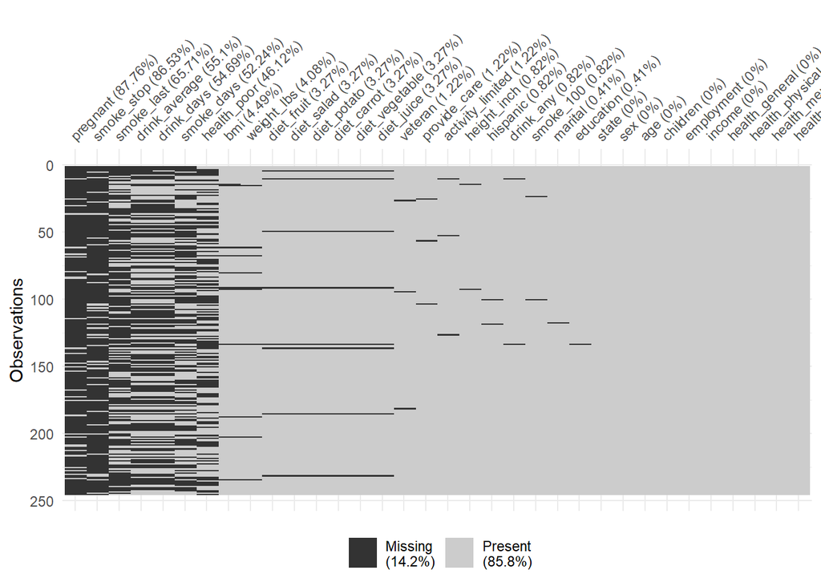

```r
# visualise and sort the columns by missingness in the `riskfactors` dataset
vis_miss(riskfactors, sort_miss = TRUE)
```

## Visualizing missing cases and variables

To get a clear picture of the missingness across variables and cases, use gg_miss_var() and gg_miss_case(). These are the visual counterpart to miss_var_summary() and miss_case_summary().

These can be split up into multiple plots with one for each category by choosing a variable to facet by.

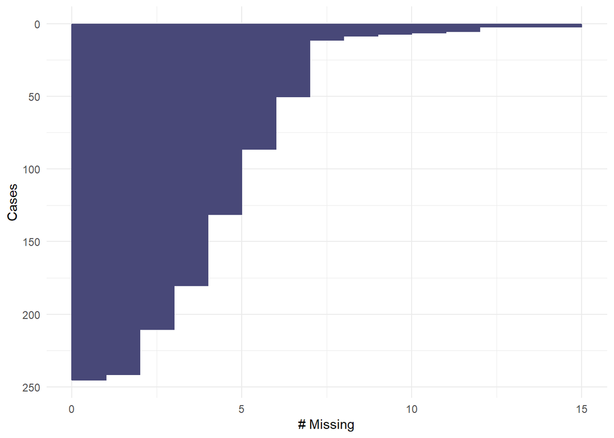

```r
# Visualize the number of missings in cases using `gg_miss_case()`
gg_miss_case(riskfactors)
```

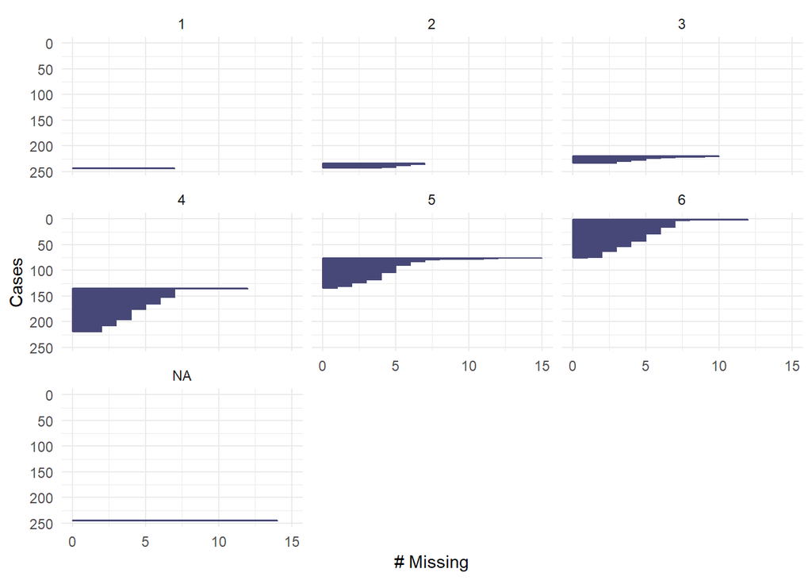

```r
# Explore the number of missings in cases using `gg_miss_case()` and facet by the variable `education`
gg_miss_case(riskfactors, facet = education)
```

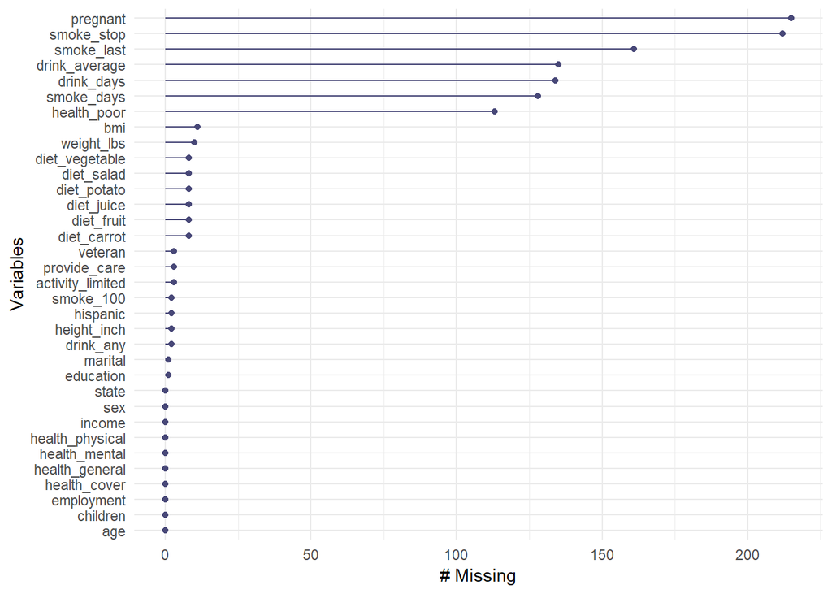

```r
# Visualize the number of missings in variables using `gg_miss_var()`
gg_miss_var(riskfactors)
```

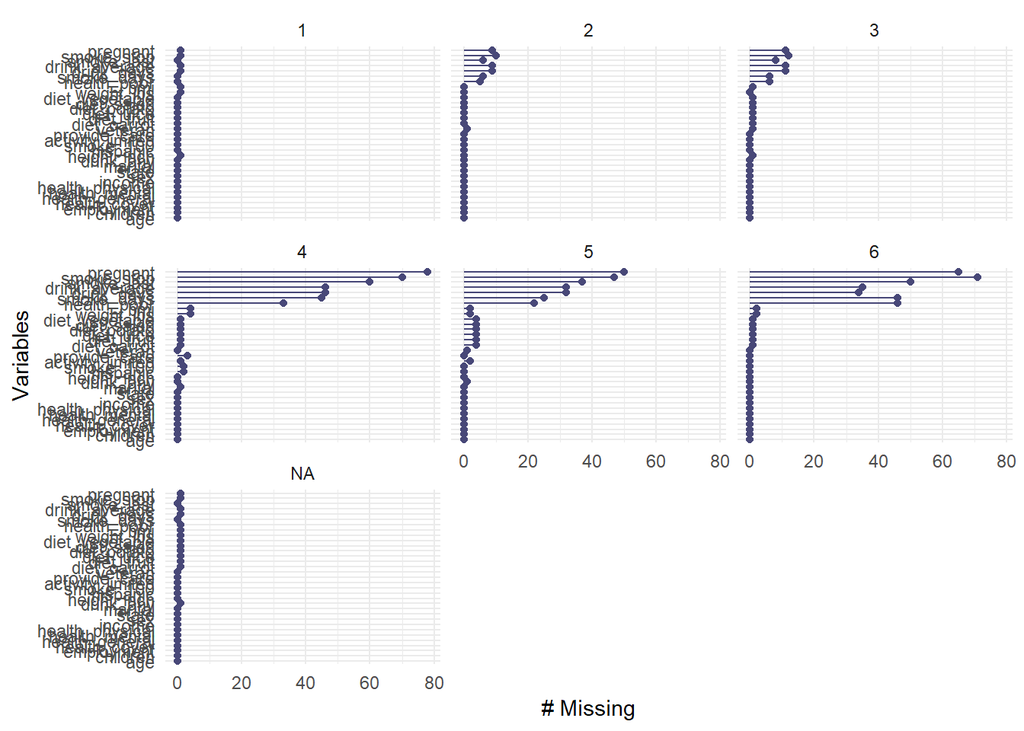

```r
# Explore the number of missings in variables using `gg_miss_var()` and facet by the variable `education`
gg_miss_var(riskfactors, facet = education)
```

## Visualising missingness patterns

Let’s practice a few different ways to vizualise patterns of missingness using: gg_miss_upset() to give an overall pattern of missingness. gg_miss_fct() for a dataset that has a factor of interest: marriage. and gg_miss_span() to explore the missingness in a time series dataset.

What do you notice with the missingness and the facetting in the data?

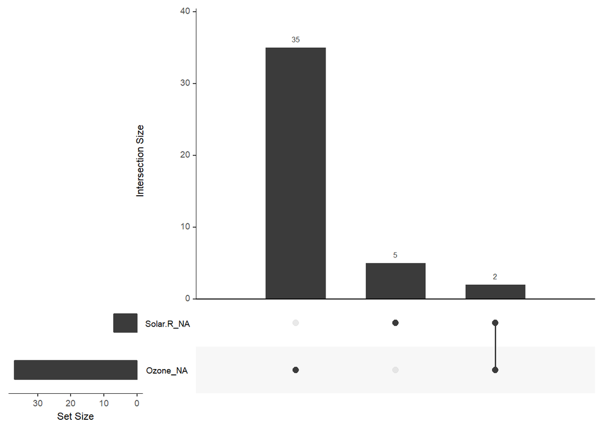

```r
# Using the airquality dataset, explore the missingness pattern using gg_miss_upset()
gg_miss_upset(airquality)
```

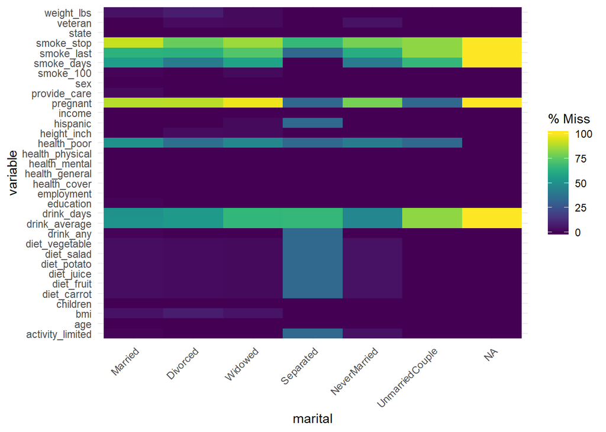

```r
# With the riskfactors dataset, explore how the missingness changes across the marital variable using gg_miss_fct()
gg_miss_fct(x = riskfactors, fct = marital)
```

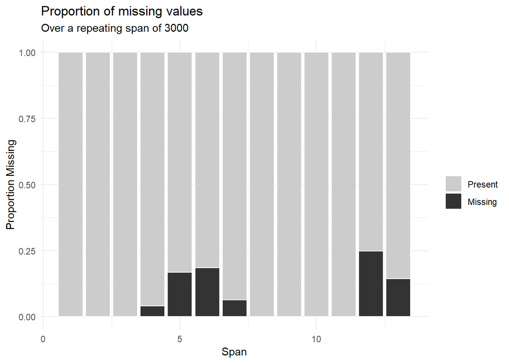

```r
# Using the pedestrian dataset, explore how the missingness of hourly_counts changes over a span of 3000
gg_miss_span(pedestrian, var = hourly_counts, span_every = 3000)
```

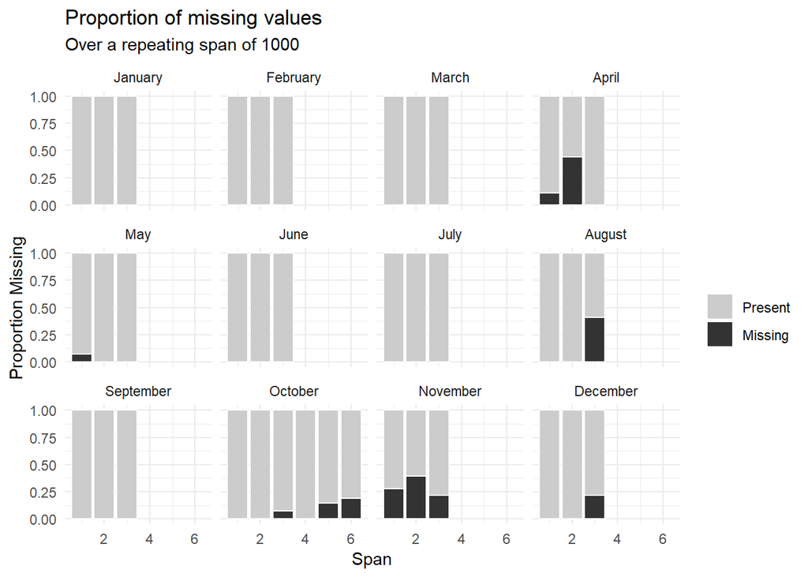

```r
# Using the pedestrian dataset, explore the impact of month by facetting by month
# and explore how missingness changes for a span of 1000
gg_miss_span(pedestrian, var = hourly_counts , span_every = 1000, facet = month)
```

## Exploring missingness dependence

To learn about the structure of the missingness in data, you can explore how sorting changes how missingness is presented.

For the oceanbuoys dataset, explore the missingness with vis_miss(), and then arrange by a few different variables

This is not a definitive process, but it will get you started to ask the right questions of your data. We explore more powerful techniques in the next chapter.

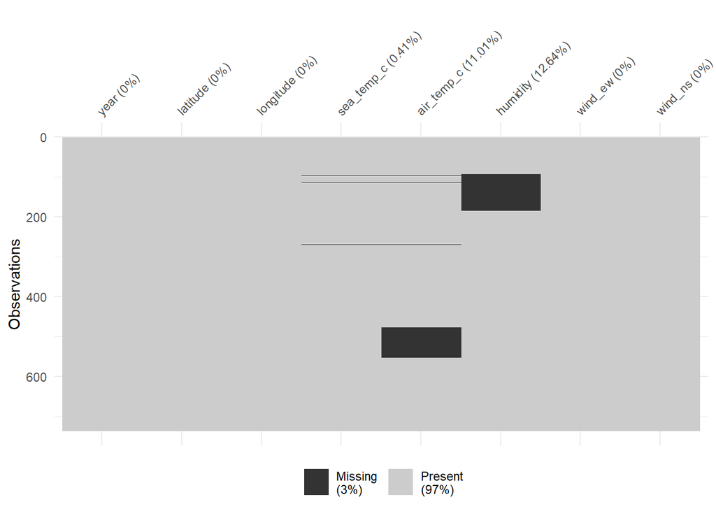

```r
oceanbuoys %>% arrange(year) %>% vis_miss()
```

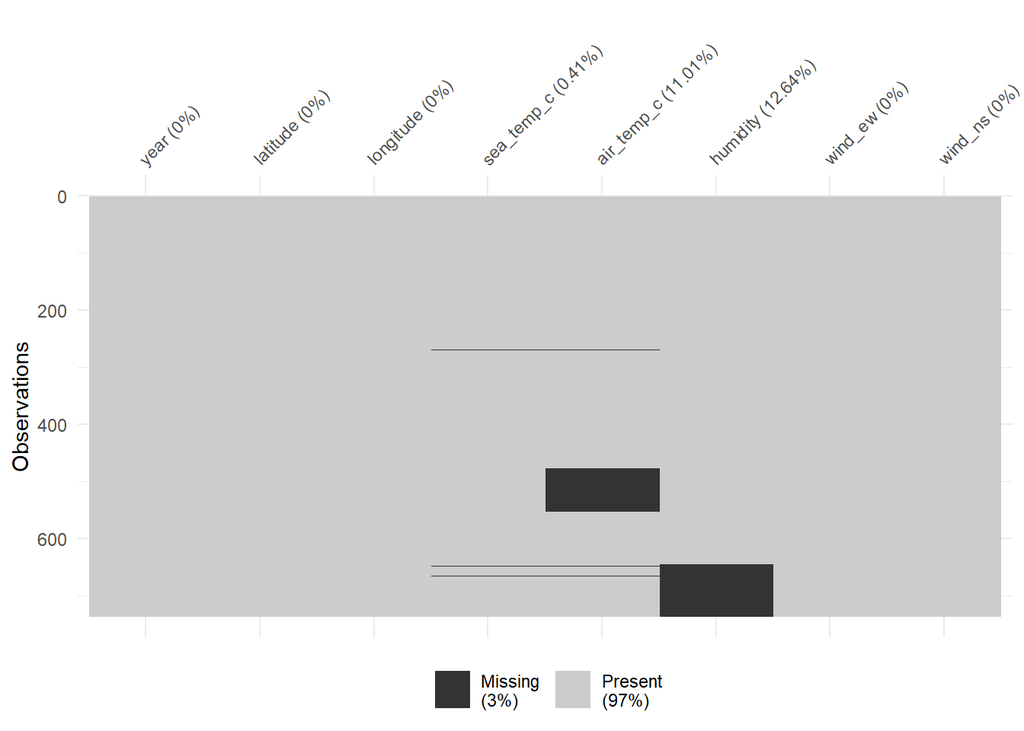

```r
oceanbuoys %>% arrange(latitude) %>% vis_miss()
```

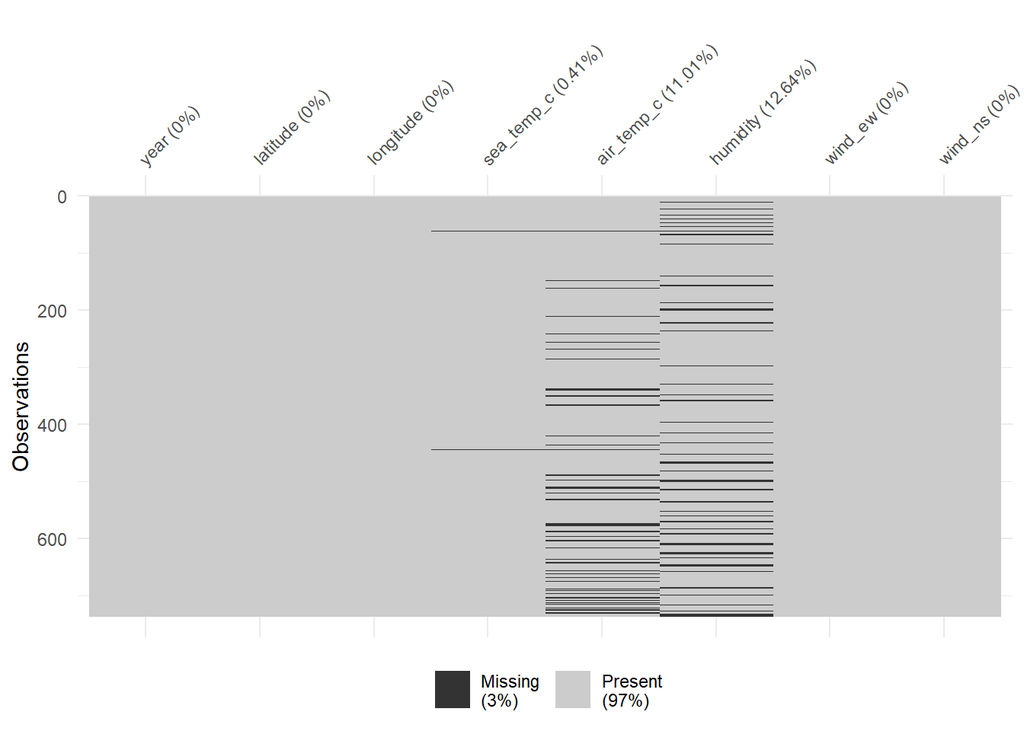

```r
oceanbuoys %>% arrange( wind_ew) %>% vis_miss()
```

# Testing missing relationships

## Creating shadow matrix data

Missing data can be tricky to think about, as they don’t usually proclaim themselves for you, and instead hide amongst the weeds of the data.

One way to help expose missing values is to change the way we think about the data - by thinking about every single data value being missing or not missing.

The as_shadow() function in R transforms a dataframe into a shadow matrix, a special data format where the values are either missing (NA), or Not Missing (!NA).

The column names of a shadow matrix are the same as the data, but have a suffix added _NA.

To keep track of and compare data values to their missingness state, use the bind_shadow() function. Having data in this format, with the shadow matrix column bound to the regular data is called nabular data.

```r
# Create shadow matrix data with `as_shadow()`
as_shadow(oceanbuoys)
```

```
## # A tibble: 736 x 8
##    year_NA latitude_NA longitude_NA sea_temp_c_NA air_temp_c_NA humidity_NA
##    <fct>   <fct>       <fct>        <fct>         <fct>         <fct>
##  1 !NA     !NA         !NA          !NA           !NA           !NA
##  2 !NA     !NA         !NA          !NA           !NA           !NA
##  3 !NA     !NA         !NA          !NA           !NA           !NA
##  4 !NA     !NA         !NA          !NA           !NA           !NA
##  5 !NA     !NA         !NA          !NA           !NA           !NA
##  6 !NA     !NA         !NA          !NA           !NA           !NA
##  7 !NA     !NA         !NA          !NA           !NA           !NA
##  8 !NA     !NA         !NA          !NA           !NA           !NA
##  9 !NA     !NA         !NA          !NA           !NA           !NA
## 10 !NA     !NA         !NA          !NA           !NA           !NA
## # ... with 726 more rows, and 2 more variables: wind_ew_NA <fct>,
## #   wind_ns_NA <fct>
```

```r
# Create nabular data by binding the shadow to the data with `bind_shadow()`
bind_shadow(oceanbuoys)
```

```
## # A tibble: 736 x 16
##     year latitude longitude sea_temp_c air_temp_c humidity wind_ew wind_ns
##    <dbl>    <dbl>     <dbl>      <dbl>      <dbl>    <dbl>   <dbl>   <dbl>
##  1  1997        0      -110       27.6       27.1     79.6   -6.40    5.40
##  2  1997        0      -110       27.5       27.0     75.8   -5.30    5.30
##  3  1997        0      -110       27.6       27       76.5   -5.10    4.5
##  4  1997        0      -110       27.6       26.9     76.2   -4.90    2.5
##  5  1997        0      -110       27.6       26.8     76.4   -3.5     4.10
##  6  1997        0      -110       27.8       26.9     76.7   -4.40    1.60
##  7  1997        0      -110       28.0       27.0     76.5   -2       3.5
##  8  1997        0      -110       28.0       27.1     78.3   -3.70    4.5
##  9  1997        0      -110       28.0       27.2     78.6   -4.20    5
## 10  1997        0      -110       28.0       27.2     76.9   -3.60    3.5
## # ... with 726 more rows, and 8 more variables: year_NA <fct>,
## #   latitude_NA <fct>, longitude_NA <fct>, sea_temp_c_NA <fct>,
## #   air_temp_c_NA <fct>, humidity_NA <fct>, wind_ew_NA <fct>,
## #   wind_ns_NA <fct>
```

```r
# Bind only the variables with missing values by using bind_shadow(only_miss = TRUE)
bind_shadow(oceanbuoys, only_miss = TRUE)
```

```
## # A tibble: 736 x 11
##     year latitude longitude sea_temp_c air_temp_c humidity wind_ew wind_ns
##    <dbl>    <dbl>     <dbl>      <dbl>      <dbl>    <dbl>   <dbl>   <dbl>
##  1  1997        0      -110       27.6       27.1     79.6   -6.40    5.40
##  2  1997        0      -110       27.5       27.0     75.8   -5.30    5.30
##  3  1997        0      -110       27.6       27       76.5   -5.10    4.5
##  4  1997        0      -110       27.6       26.9     76.2   -4.90    2.5
##  5  1997        0      -110       27.6       26.8     76.4   -3.5     4.10
##  6  1997        0      -110       27.8       26.9     76.7   -4.40    1.60
##  7  1997        0      -110       28.0       27.0     76.5   -2       3.5
##  8  1997        0      -110       28.0       27.1     78.3   -3.70    4.5
##  9  1997        0      -110       28.0       27.2     78.6   -4.20    5
## 10  1997        0      -110       28.0       27.2     76.9   -3.60    3.5
## # ... with 726 more rows, and 3 more variables: sea_temp_c_NA <fct>,
## #   air_temp_c_NA <fct>, humidity_NA <fct>
```